# Descripción del Proyecto

Trabajamos para la tienda online Ice que vende videojuegos por todo el mundo. Las reseñas de usuarios y expertos, los géneros, las plataformas (por ejemplo, Xbox o PlayStation) y los datos históricos sobre las ventas de juegos están disponibles en fuentes abiertas. Debemos identificar patrones que determinen si un juego tiene éxito o no. Esto nos permitirá detectar proyectos prometedores y planificar campañas publicitarias.

El dataset contiene la abreviatura ESRB. The Entertainment Software Rating Board (la Junta de clasificación de software de entretenimiento) evalúa el contenido de un juego y asigna una clasificación de edad como Adolescente o Adulto.

Lo datos proporcionados se remontan al año 2016.

# Tabla de contenidos

## Inicialización

```python
# Cargamos todas las librerías a usar
import pandas as pd
from IPython.display import display, HTML
import matplotlib.pyplot as plt
import math
import numpy as np #libreria calculos numericos
from scipy import stats as st  #lbreria estadistica
import warnings

warnings.filterwarnings("ignore") #para ignorar advertencias
#warnings.filterwarnings("default") #para volver a ver advertencias

#colores para usar mas adelante en los gráficos
azul='#1f77b4'
naranja='#ff7f0e'
```

```python
#Definimos una función Print que sea vizualmente mas amigable
def print_mejorado(texto,size):
    size=str(size)
    display(HTML('<span style="font-size: '+size+'px;">'+texto+'</span>'))

#Establecemos el número de filas que se pueden ver simulataneamente en 100 (para mejor vizualización)
pd.set_option('display.max_rows', None)
```

## Cargar los datos

```python
# Carga los archivos de datos en diferentes DataFrames
data=pd.read_csv('/datasets/games.csv')
```

## Revisión de los datos

```python
data.info()
```

```
<class 'pandas.core.frame.DataFrame'>
RangeIndex: 16715 entries, 0 to 16714
Data columns (total 11 columns):
 #   Column           Non-Null Count  Dtype
---  ------           --------------  -----
 0   Name             16713 non-null  object
 1   Platform         16715 non-null  object
 2   Year_of_Release  16446 non-null  float64
 3   Genre            16713 non-null  object
 4   NA_sales         16715 non-null  float64
 5   EU_sales         16715 non-null  float64
 6   JP_sales         16715 non-null  float64
 7   Other_sales      16715 non-null  float64
 8   Critic_Score     8137 non-null   float64
 9   User_Score       10014 non-null  object
 10  Rating           9949 non-null   object
dtypes: float64(6), object(5)
memory usage: 1.4+ MB
```

```python
# Imprimimos una muestra pequeña de nuestros datos
data.head(10)
```

|  | Name | Platform | Year_of_Release | Genre | NA_sales | EU_sales | JP_sales | Other_sales | Critic_Score | User_Score | Rating |
| --- | --- | --- | --- | --- | --- | --- | --- | --- | --- | --- | --- |
| 0 | Wii Sports | Wii | 2006.0 | Sports | 41.36 | 28.96 | 3.77 | 8.45 | 76.0 | 8 | E |
| 1 | Super Mario Bros. | NES | 1985.0 | Platform | 29.08 | 3.58 | 6.81 | 0.77 | NaN | NaN | NaN |
| 2 | Mario Kart Wii | Wii | 2008.0 | Racing | 15.68 | 12.76 | 3.79 | 3.29 | 82.0 | 8.3 | E |
| 3 | Wii Sports Resort | Wii | 2009.0 | Sports | 15.61 | 10.93 | 3.28 | 2.95 | 80.0 | 8 | E |
| 4 | Pokemon Red/Pokemon Blue | GB | 1996.0 | Role-Playing | 11.27 | 8.89 | 10.22 | 1.00 | NaN | NaN | NaN |
| 5 | Tetris | GB | 1989.0 | Puzzle | 23.20 | 2.26 | 4.22 | 0.58 | NaN | NaN | NaN |
| 6 | New Super Mario Bros. | DS | 2006.0 | Platform | 11.28 | 9.14 | 6.50 | 2.88 | 89.0 | 8.5 | E |
| 7 | Wii Play | Wii | 2006.0 | Misc | 13.96 | 9.18 | 2.93 | 2.84 | 58.0 | 6.6 | E |
| 8 | New Super Mario Bros. Wii | Wii | 2009.0 | Platform | 14.44 | 6.94 | 4.70 | 2.24 | 87.0 | 8.4 | E |
| 9 | Duck Hunt | NES | 1984.0 | Shooter | 26.93 | 0.63 | 0.28 | 0.47 | NaN | NaN | NaN |

*Nuestro set de datos consta de 16715 filas*  
*Hay datos nulos en las tablas `Name`,`Year_of_Release`, `Genre`,`Critic_Score`,`User_Score` y`Rating`.*  
*La columna `User_Score` es tipo Object y debe ser transformada a float64.*

```python
#Revisamos si existen datos duplicados implicitos
print_mejorado(f"La lista de juegos unicos es de {len(data['Name'].unique())}",24)
data['Name'].unique()
```

La lista de juegos unicos es de 11560

```
array(['Wii Sports', 'Super Mario Bros.', 'Mario Kart Wii', ...,
       'Woody Woodpecker in Crazy Castle 5', 'LMA Manager 2007',
       'Haitaka no Psychedelica'], dtype=object)
```

```python
#Revisamos si existen datos duplicados implicitos
data['Platform'].unique()
```

```
array(['Wii', 'NES', 'GB', 'DS', 'X360', 'PS3', 'PS2', 'SNES', 'GBA',
       'PS4', '3DS', 'N64', 'PS', 'XB', 'PC', '2600', 'PSP', 'XOne',
       'WiiU', 'GC', 'GEN', 'DC', 'PSV', 'SAT', 'SCD', 'WS', 'NG', 'TG16',
       '3DO', 'GG', 'PCFX'], dtype=object)
```

```python
#Creamos funcion para visualizar rapidamente histogramas y datos descriptivos de cada columna
def histo_des(df):
    fig, (ax1, ax2) = plt.subplots(nrows=1, ncols=2, figsize=(20, 8))
    df.hist(ax=ax1,bins=20, figsize=(20,5))
    ax1.set_xlabel('Valores')
    ax1.set_ylabel('Frecuencia')
    ax1.set_title(df.name)

    ax2.axis('off')
    ax2.text(0, 0.5, str(df.describe()), fontsize=20, va='center')
    plt.subplots_adjust(wspace=0.5)
    plt.show()
```

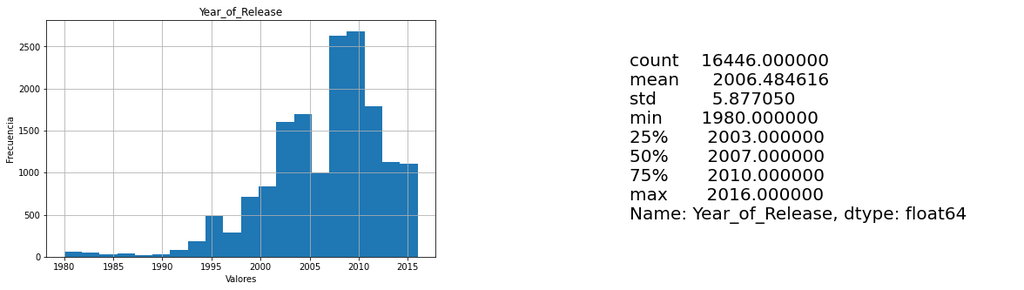

```python
#Revisamos si existen datos fuera de rango usando un histograma
histo_des(data['Year_of_Release'])
```

```python
#Revisamos si existen datos duplicados implicitos
data['Genre'].unique()
```

```
array(['Sports', 'Platform', 'Racing', 'Role-Playing', 'Puzzle', 'Misc',
       'Shooter', 'Simulation', 'Action', 'Fighting', 'Adventure',
       'Strategy', nan], dtype=object)
```

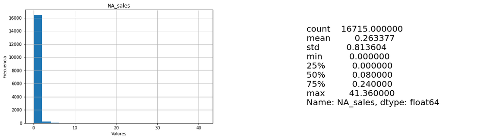

```python
#Analizamos la distribución de precios en NA
histo_des(data['NA_sales'])
```

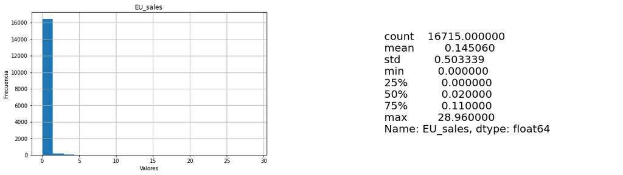

```python
#Analizamos la distribución de precios en Europa
histo_des(data['EU_sales'])
```

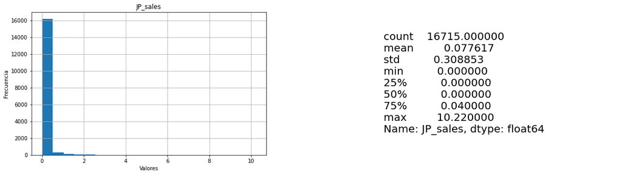

```python
#Analizamos la distribución de precios en Japon
histo_des(data['JP_sales'])
```

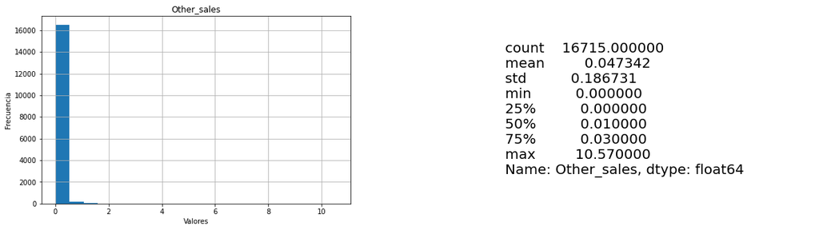

```python
#Analizamos la distribución de precios en el resto del mundo
histo_des(data['Other_sales'])
```

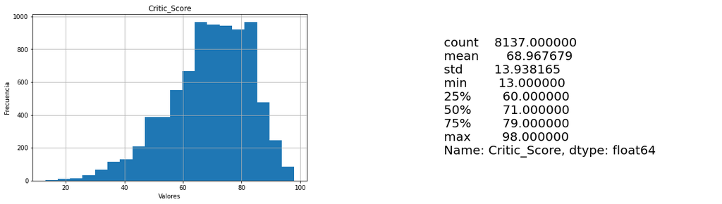

```python
#Analizamos la distribución de calificaciones dadas por la crítica
histo_des(data['Critic_Score'])
```

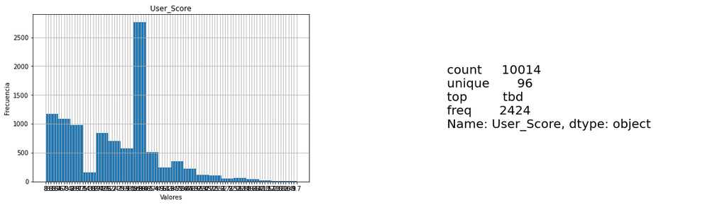

```python
#Analizamos la distribución de calificaciones dadas por los usuarios
histo_des(data['User_Score'])
```

*Dado que `User_Score` es tipo Object, no se vizualiza claramente el histograma, ademas, se aprecia un valor string "tbd" que corresponde a "To be determinated", el cual probablemente fue el responasble de convertir la columna de float64 a Object. Mas adelante en la fase de correción se abordará esta columna en profundidad*

```python
#Revisamos si existen datos duplicados implicitos
data['Rating'].unique()
```

```
array(['E', nan, 'M', 'T', 'E10+', 'K-A', 'AO', 'EC', 'RP'], dtype=object)
```

### Conclusiones iniciales

- No se puede determinar facilmente si la columna `Name` posee datos implicitos dado que tiene un total de 11560 titulos diferentes.
- No hay datos inplicitos en `Platform`,`Genre` y `Rating`

Respecto a las columnas con datos númericos, tras revisar los histogramas vemos que:

- Los datos de Año de salida, se encuentra dentro de lo esperado (1980-2016)
- Las ganancias (en millones de dolares) se encuentran en rangos aceptables.
- Las calificaciones de la critica estan en rangos aceptables (0-100)
- Es necesario corregir y mirar en detalle la columna `User_Score`

## Corrección de datos

### Corregimos los valores nulos en `Name`

```python
data.query('Name.isna()')
```

|  | Name | Platform | Year_of_Release | Genre | NA_sales | EU_sales | JP_sales | Other_sales | Critic_Score | User_Score | Rating |
| --- | --- | --- | --- | --- | --- | --- | --- | --- | --- | --- | --- |
| 659 | NaN | GEN | 1993.0 | NaN | 1.78 | 0.53 | 0.00 | 0.08 | NaN | NaN | NaN |
| 14244 | NaN | GEN | 1993.0 | NaN | 0.00 | 0.00 | 0.03 | 0.00 | NaN | NaN | NaN |

Hay solo dos filas con valores nulos en `Name`, correpondienes al año 1993 para un juego de la consola GEN. Estas dos filas no aportan en nada y son desprecibles en relación al conjutno de datos que disponemos. Se procederá a borrarlas.

```python
data.dropna(subset=['Name'], inplace=True)
data.info()
```

```
<class 'pandas.core.frame.DataFrame'>
Int64Index: 16713 entries, 0 to 16714
Data columns (total 11 columns):
 #   Column           Non-Null Count  Dtype
---  ------           --------------  -----
 0   Name             16713 non-null  object
 1   Platform         16713 non-null  object
 2   Year_of_Release  16444 non-null  float64
 3   Genre            16713 non-null  object
 4   NA_sales         16713 non-null  float64
 5   EU_sales         16713 non-null  float64
 6   JP_sales         16713 non-null  float64
 7   Other_sales      16713 non-null  float64
 8   Critic_Score     8137 non-null   float64
 9   User_Score       10014 non-null  object
 10  Rating           9949 non-null   object
dtypes: float64(6), object(5)
memory usage: 1.5+ MB
```

Al eliminar las dos filas nulas en `Name`, sin querelo, corregimos tambien la columna `Genre`, la cual ya no tiene datos nulos.

### Corregimos (si es posible) los valores nulos en `Year_of_Release`

```python
#Imprimimos una muestra de alguno datos nulos de esta columna
data.query('Year_of_Release.isna()').head(10)
```

|  | Name | Platform | Year_of_Release | Genre | NA_sales | EU_sales | JP_sales | Other_sales | Critic_Score | User_Score | Rating |
| --- | --- | --- | --- | --- | --- | --- | --- | --- | --- | --- | --- |
| 183 | Madden NFL 2004 | PS2 | NaN | Sports | 4.26 | 0.26 | 0.01 | 0.71 | 94.0 | 8.5 | E |
| 377 | FIFA Soccer 2004 | PS2 | NaN | Sports | 0.59 | 2.36 | 0.04 | 0.51 | 84.0 | 6.4 | E |
| 456 | LEGO Batman: The Videogame | Wii | NaN | Action | 1.80 | 0.97 | 0.00 | 0.29 | 74.0 | 7.9 | E10+ |
| 475 | wwe Smackdown vs. Raw 2006 | PS2 | NaN | Fighting | 1.57 | 1.02 | 0.00 | 0.41 | NaN | NaN | NaN |
| 609 | Space Invaders | 2600 | NaN | Shooter | 2.36 | 0.14 | 0.00 | 0.03 | NaN | NaN | NaN |
| 627 | Rock Band | X360 | NaN | Misc | 1.93 | 0.33 | 0.00 | 0.21 | 92.0 | 8.2 | T |
| 657 | Frogger's Adventures: Temple of the Frog | GBA | NaN | Adventure | 2.15 | 0.18 | 0.00 | 0.07 | 73.0 | tbd | E |
| 678 | LEGO Indiana Jones: The Original Adventures | Wii | NaN | Action | 1.51 | 0.61 | 0.00 | 0.21 | 78.0 | 6.6 | E10+ |
| 719 | Call of Duty 3 | Wii | NaN | Shooter | 1.17 | 0.84 | 0.00 | 0.23 | 69.0 | 6.7 | T |
| 805 | Rock Band | Wii | NaN | Misc | 1.33 | 0.56 | 0.00 | 0.20 | 80.0 | 6.3 | T |

```python
#Analizamos las consolas a las que pertenecen estos videojuegos
data.query('Year_of_Release.isna()').pivot_table(index='Platform',values='NA_sales', aggfunc='count')
```

| Platform | NA_sales |
| --- | --- |
| 2600 | 17 |
| 3DS | 8 |
| DS | 30 |
| GB | 1 |
| GBA | 11 |
| GC | 14 |
| N64 | 3 |
| PC | 17 |
| PS | 7 |
| PS2 | 34 |
| PS3 | 25 |
| PSP | 16 |
| PSV | 1 |
| Wii | 34 |
| X360 | 30 |
| XB | 21 |

```python
#Analizamos los géneros a las que pertenecen estos videojuegos
data.query('Year_of_Release.isna()').pivot_table(index='Genre',values='NA_sales', aggfunc='count')
```

| Genre | NA_sales |
| --- | --- |
| Action | 62 |
| Adventure | 10 |
| Fighting | 12 |
| Misc | 29 |
| Platform | 10 |
| Puzzle | 11 |
| Racing | 23 |
| Role-Playing | 17 |
| Shooter | 27 |
| Simulation | 16 |
| Sports | 42 |
| Strategy | 10 |

```python
#Cuando uso np.nan luego no me deja convertir a int
data['Year_of_Release'].fillna(np.nan, inplace=True)
data.info()
```

```
<class 'pandas.core.frame.DataFrame'>
Int64Index: 16713 entries, 0 to 16714
Data columns (total 11 columns):
 #   Column           Non-Null Count  Dtype
---  ------           --------------  -----
 0   Name             16713 non-null  object
 1   Platform         16713 non-null  object
 2   Year_of_Release  16444 non-null  float64
 3   Genre            16713 non-null  object
 4   NA_sales         16713 non-null  float64
 5   EU_sales         16713 non-null  float64
 6   JP_sales         16713 non-null  float64
 7   Other_sales      16713 non-null  float64
 8   Critic_Score     8137 non-null   float64
 9   User_Score       10014 non-null  object
 10  Rating           9949 non-null   object
dtypes: float64(6), object(5)
memory usage: 1.5+ MB
```

### Corregimos los valores nulos en `Critic_Score`:

Como vimos anteriormente en el histograma de esta columna, todos los valores se encuentran en un rango de 0 a 100 (lo cual es correcto). Pero existe una gran cantidad de datos ausentes.

```python
print("\n")
aux=len(data.query('Critic_Score.isna()'))
aux2= aux/len(data)
print_mejorado(f"Los juegos sin calificación (valores ausentes) son {aux} ({aux2:.1%})",24)
print("\n")
```

Los juegos sin calificación (valores ausentes) son 8576 (51.3%)

```python
#data['Critic_Score'].fillna(-1, inplace=True)
data['Critic_Score'].fillna(np.nan, inplace=True)
data.info()
```

```
<class 'pandas.core.frame.DataFrame'>
Int64Index: 16713 entries, 0 to 16714
Data columns (total 11 columns):
 #   Column           Non-Null Count  Dtype
---  ------           --------------  -----
 0   Name             16713 non-null  object
 1   Platform         16713 non-null  object
 2   Year_of_Release  16444 non-null  float64
 3   Genre            16713 non-null  object
 4   NA_sales         16713 non-null  float64
 5   EU_sales         16713 non-null  float64
 6   JP_sales         16713 non-null  float64
 7   Other_sales      16713 non-null  float64
 8   Critic_Score     8137 non-null   float64
 9   User_Score       10014 non-null  object
 10  Rating           9949 non-null   object
dtypes: float64(6), object(5)
memory usage: 1.5+ MB
```

### Corregimos los valores nulos en `User_Score`

Como vimos anteriormente, esta columna es tipo objeto. Analicemos los valores unicos.

```python
data['User_Score'].unique()
```

```
array(['8', nan, '8.3', '8.5', '6.6', '8.4', '8.6', '7.7', '6.3', '7.4',
       '8.2', '9', '7.9', '8.1', '8.7', '7.1', '3.4', '5.3', '4.8', '3.2',
       '8.9', '6.4', '7.8', '7.5', '2.6', '7.2', '9.2', '7', '7.3', '4.3',
       '7.6', '5.7', '5', '9.1', '6.5', 'tbd', '8.8', '6.9', '9.4', '6.8',
       '6.1', '6.7', '5.4', '4', '4.9', '4.5', '9.3', '6.2', '4.2', '6',
       '3.7', '4.1', '5.8', '5.6', '5.5', '4.4', '4.6', '5.9', '3.9',
       '3.1', '2.9', '5.2', '3.3', '4.7', '5.1', '3.5', '2.5', '1.9', '3',
       '2.7', '2.2', '2', '9.5', '2.1', '3.6', '2.8', '1.8', '3.8', '0',
       '1.6', '9.6', '2.4', '1.7', '1.1', '0.3', '1.5', '0.7', '1.2',
       '2.3', '0.5', '1.3', '0.2', '0.6', '1.4', '0.9', '1', '9.7'],
      dtype=object)
```

Aquí vemos que la mayoría de los datos son numericos a excepción de "tba" (to be determinated) que es un string y de los valores ausentes (nan). Veamos a que porcentaje de nuestro de set de datos corresponden estos valores.

```python
print("\n")
aux=len(data.query('User_Score=="tbd"'))
aux2= aux/len(data)
print_mejorado(f"Los juegos con una calificación de usuarios pendiente (tbd) son {aux} ({aux2:.1%})",24)
aux=len(data.query('User_Score.isna()'))
aux2= aux/len(data)
print_mejorado(f"Los juegos sin calificación (valores ausentes) son {aux} ({aux2:.1%})",24)
print("\n")
```

Los juegos con una calificación de usuarios pendiente (tbd) son 2424 (14.5%)

Los juegos sin calificación (valores ausentes) son 6699 (40.1%)

```python
data['User_Score'].fillna(np.nan, inplace=True)
data['User_Score'].replace("tbd", np.nan, inplace=True)
data['User_Score'] = data['User_Score'].astype('float64')
data.info()
```

```
<class 'pandas.core.frame.DataFrame'>
Int64Index: 16713 entries, 0 to 16714
Data columns (total 11 columns):
 #   Column           Non-Null Count  Dtype
---  ------           --------------  -----
 0   Name             16713 non-null  object
 1   Platform         16713 non-null  object
 2   Year_of_Release  16444 non-null  float64
 3   Genre            16713 non-null  object
 4   NA_sales         16713 non-null  float64
 5   EU_sales         16713 non-null  float64
 6   JP_sales         16713 non-null  float64
 7   Other_sales      16713 non-null  float64
 8   Critic_Score     8137 non-null   float64
 9   User_Score       7590 non-null   float64
 10  Rating           9949 non-null   object
dtypes: float64(7), object(4)
memory usage: 1.5+ MB
```

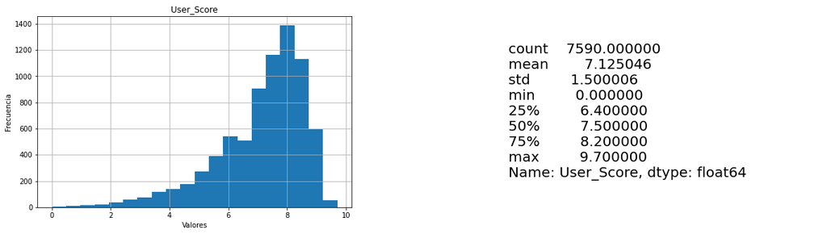

```python
#histo_des(data.query('User_Score!=-1')['User_Score'])
histo_des(data['User_Score'])
```

Corregimos (si es posible) los valores nulos en `Rating`.

Como ya se vio anteriormente en la Revisión de datos,al observar los valores únicos de esta columna, vemos que existen 8 categorias, todas pertenecientes a la clasificación ESRB.

```python
data['Rating'].fillna("Unknown", inplace=True)
data.info()
```

```
<class 'pandas.core.frame.DataFrame'>
Int64Index: 16713 entries, 0 to 16714
Data columns (total 11 columns):
 #   Column           Non-Null Count  Dtype
---  ------           --------------  -----
 0   Name             16713 non-null  object
 1   Platform         16713 non-null  object
 2   Year_of_Release  16444 non-null  float64
 3   Genre            16713 non-null  object
 4   NA_sales         16713 non-null  float64
 5   EU_sales         16713 non-null  float64
 6   JP_sales         16713 non-null  float64
 7   Other_sales      16713 non-null  float64
 8   Critic_Score     8137 non-null   float64
 9   User_Score       7590 non-null   float64
 10  Rating           16713 non-null  object
dtypes: float64(7), object(4)
memory usage: 1.5+ MB
```

### Buscamos duplicados explicitos

Buscamos y eliminamos (si existen) el número de duplicados obvios en nuestro Dataframe

```python
# contando duplicados obvios
print("\n")
print_mejorado(f"Hay {data.duplicated().sum()} duplicados explicitos",24)
print("\n")
```

Hay 0 duplicados explicitos

## Analisis de los datos

### Contabilizamos la cantidad de juegos lanzados por año

```python
data.head(10)
```

|  | Name | Platform | Year_of_Release | Genre | NA_sales | EU_sales | JP_sales | Other_sales | Critic_Score | User_Score | Rating |
| --- | --- | --- | --- | --- | --- | --- | --- | --- | --- | --- | --- |
| 0 | Wii Sports | Wii | 2006.0 | Sports | 41.36 | 28.96 | 3.77 | 8.45 | 76.0 | 8.0 | E |
| 1 | Super Mario Bros. | NES | 1985.0 | Platform | 29.08 | 3.58 | 6.81 | 0.77 | NaN | NaN | Unknown |
| 2 | Mario Kart Wii | Wii | 2008.0 | Racing | 15.68 | 12.76 | 3.79 | 3.29 | 82.0 | 8.3 | E |
| 3 | Wii Sports Resort | Wii | 2009.0 | Sports | 15.61 | 10.93 | 3.28 | 2.95 | 80.0 | 8.0 | E |
| 4 | Pokemon Red/Pokemon Blue | GB | 1996.0 | Role-Playing | 11.27 | 8.89 | 10.22 | 1.00 | NaN | NaN | Unknown |
| 5 | Tetris | GB | 1989.0 | Puzzle | 23.20 | 2.26 | 4.22 | 0.58 | NaN | NaN | Unknown |
| 6 | New Super Mario Bros. | DS | 2006.0 | Platform | 11.28 | 9.14 | 6.50 | 2.88 | 89.0 | 8.5 | E |
| 7 | Wii Play | Wii | 2006.0 | Misc | 13.96 | 9.18 | 2.93 | 2.84 | 58.0 | 6.6 | E |
| 8 | New Super Mario Bros. Wii | Wii | 2009.0 | Platform | 14.44 | 6.94 | 4.70 | 2.24 | 87.0 | 8.4 | E |
| 9 | Duck Hunt | NES | 1984.0 | Shooter | 26.93 | 0.63 | 0.28 | 0.47 | NaN | NaN | Unknown |

```python
#data.pivot_table(index='Year_of_Release', aggfunc="count")
juegos_por_año=data.groupby('Year_of_Release').size().reset_index(name='Cantidad').sort_values(by='Year_of_Release')
juegos_por_año
```

|  | Year_of_Release | Cantidad |
| --- | --- | --- |
| 0 | 1980.0 | 9 |
| 1 | 1981.0 | 46 |
| 2 | 1982.0 | 36 |
| 3 | 1983.0 | 17 |
| 4 | 1984.0 | 14 |
| 5 | 1985.0 | 14 |
| 6 | 1986.0 | 21 |
| 7 | 1987.0 | 16 |
| 8 | 1988.0 | 15 |
| 9 | 1989.0 | 17 |
| 10 | 1990.0 | 16 |
| 11 | 1991.0 | 41 |
| 12 | 1992.0 | 43 |
| 13 | 1993.0 | 60 |
| 14 | 1994.0 | 121 |
| 15 | 1995.0 | 219 |
| 16 | 1996.0 | 263 |
| 17 | 1997.0 | 289 |
| 18 | 1998.0 | 379 |
| 19 | 1999.0 | 338 |
| 20 | 2000.0 | 350 |
| 21 | 2001.0 | 482 |
| 22 | 2002.0 | 829 |
| 23 | 2003.0 | 775 |
| 24 | 2004.0 | 762 |
| 25 | 2005.0 | 939 |
| 26 | 2006.0 | 1006 |
| 27 | 2007.0 | 1197 |
| 28 | 2008.0 | 1427 |
| 29 | 2009.0 | 1426 |
| 30 | 2010.0 | 1255 |
| 31 | 2011.0 | 1136 |
| 32 | 2012.0 | 653 |
| 33 | 2013.0 | 544 |
| 34 | 2014.0 | 581 |
| 35 | 2015.0 | 606 |
| 36 | 2016.0 | 502 |

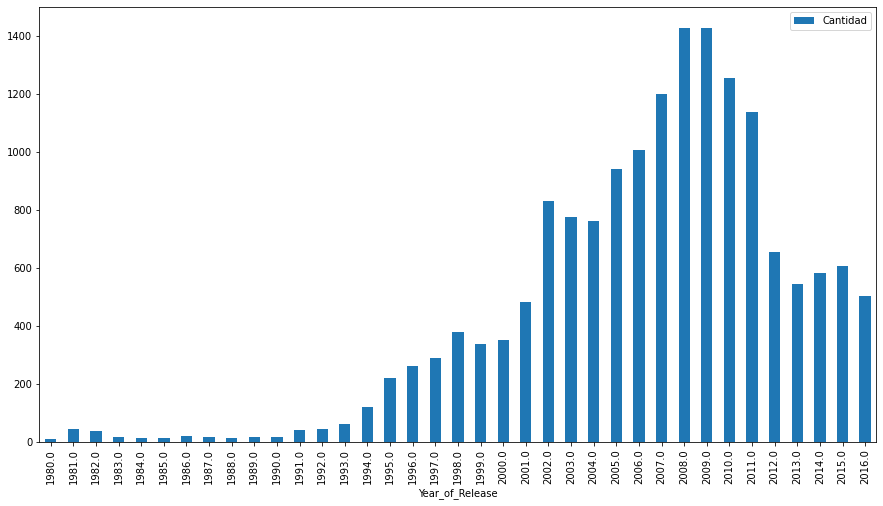

```python
juegos_por_año.plot(kind="bar",x='Year_of_Release', figsize=(15,8))
```

### Definimos un nuevo Dataset mas afin a nuestras necesidades

Llegados a este punto, es importante deternos a pensar si es que vale la pena utilizar toda la base de datos para los analisis posteriores. Teniendo en cuenta que nuestro objetivo es determinar una estrategia para el año 2017, no tiene sentido utilizar infomación desactualizada, dado que los tiempos y tendencias cambian (nuevas consolas, modas, cultura, etc). En base a esto, y observando la gráfica de titulos lanzados por año (arriba), según MI criterio, me parece sensato utilizar solo la información de los últimos 5 años (2012,2013,2014,2015 y 2016), viendo que ademas, en este periodo, los juegos lanzados por año tienden a estabilizarse en un numero cercano a 500 juegos por año.

A continuación crearé un nuevo dataset con lo descrito anteriormente y descartando ademas los titulos con fechas de lanzamiento desconocidas (-1).

```python
data_actual= data.query('Year_of_Release>=2012')
```

Ahora haré un analisis rápido de nuestro nuevo dataset:

```
<class 'pandas.core.frame.DataFrame'>
Int64Index: 2886 entries, 16 to 16714
Data columns (total 11 columns):
 #   Column           Non-Null Count  Dtype
---  ------           --------------  -----
 0   Name             2886 non-null   object
 1   Platform         2886 non-null   object
 2   Year_of_Release  2886 non-null   float64
 3   Genre            2886 non-null   object
 4   NA_sales         2886 non-null   float64
 5   EU_sales         2886 non-null   float64
 6   JP_sales         2886 non-null   float64
 7   Other_sales      2886 non-null   float64
 8   Critic_Score     1312 non-null   float64
 9   User_Score       1531 non-null   float64
 10  Rating           2886 non-null   object
dtypes: float64(7), object(4)
memory usage: 270.6+ KB
```

En el nuevo Dataframe(2012-2016):

Hay 2886 filas (17.3% del dataframe original)

Juegos por año

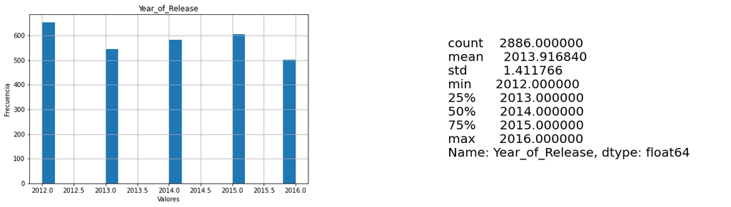

Ventas en distintas regiones

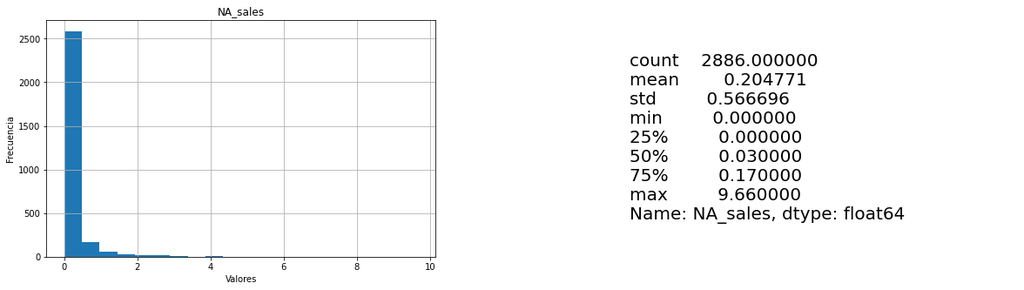

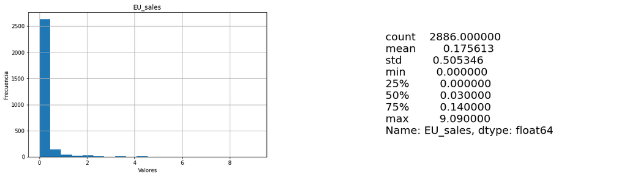

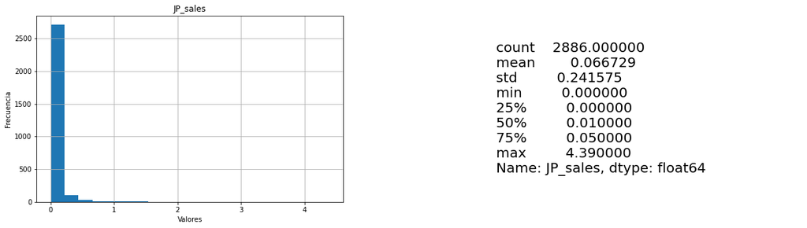

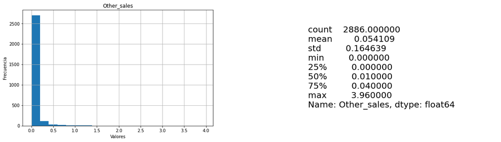

Puntaciones de la Crítica y los usuarios (no se consideran los valores nulos)

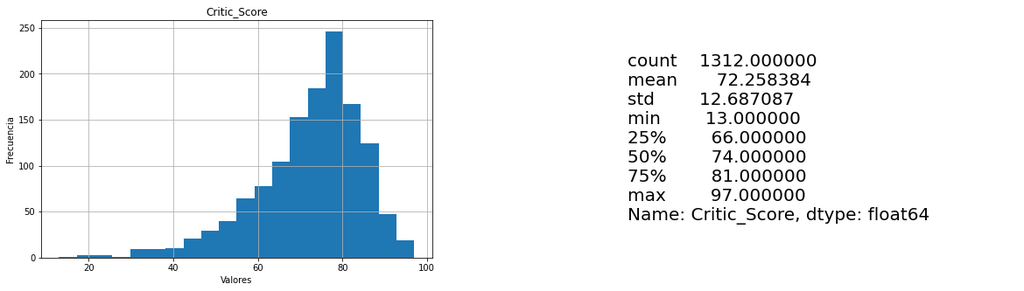

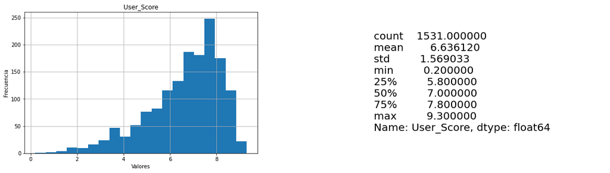

```python
data_actual.info()

print_mejorado("En el nuevo Dataframe(2012-2016):", 24)
aux=len(data_actual)
aux2=aux/len(data)
print_mejorado(f"Hay {aux} filas ({aux2:.1%} del dataframe original) ",20)
print("\n")

print_mejorado("Juegos por año",24)
histo_des(data_actual['Year_of_Release'])
print_mejorado("Ventas en distintas regiones",24)
histo_des(data_actual['NA_sales'])
histo_des(data_actual['EU_sales'])
histo_des(data_actual['JP_sales'])
histo_des(data_actual['Other_sales'])
print_mejorado("Puntaciones de la Crítica y los usuarios (no se consideran los valores nulos)",24)
histo_des(data_actual.query('Critic_Score>-1')['Critic_Score'])
histo_des(data_actual.query('User_Score>-1')['User_Score'])


aux=len(data_actual.query('Critic_Score==-1'))
aux2=aux/len(data_actual)
print_mejorado(f"Hay {aux} filas sin puntación de la crítica ({aux2:.1%} de los datos) ",20)
aux=len(data_actual.query('User_Score==-1'))
aux2=aux/len(data_actual)
print_mejorado(f"Hay {aux} filas sin puntación de los usuarios ({aux2:.1%} de los datos) ",20)
```

[output not shown]

### Analisis de ingresos por plafaformas (2012-2016)

Observa cómo varían las ventas de una plataforma a otra. Elige las plataformas con las mayores ventas totales y construye una distribución basada en los datos de cada año. Busca las plataformas que solían ser populares pero que ahora no tienen ventas. ¿Cuánto tardan generalmente las nuevas plataformas en aparecer y las antiguas en desaparecer?

```python
#Enriquecemos nuestros DF agregando una nueva columna con los ingresos totales
data_actual['total_sales']=data_actual['NA_sales']+data_actual['EU_sales']+data_actual['JP_sales']+data_actual['Other_sales']
data_actual.info()
```

```
<class 'pandas.core.frame.DataFrame'>
Int64Index: 2886 entries, 16 to 16714
Data columns (total 12 columns):
 #   Column           Non-Null Count  Dtype
---  ------           --------------  -----
 0   Name             2886 non-null   object
 1   Platform         2886 non-null   object
 2   Year_of_Release  2886 non-null   float64
 3   Genre            2886 non-null   object
 4   NA_sales         2886 non-null   float64
 5   EU_sales         2886 non-null   float64
 6   JP_sales         2886 non-null   float64
 7   Other_sales      2886 non-null   float64
 8   Critic_Score     1312 non-null   float64
 9   User_Score       1531 non-null   float64
 10  Rating           2886 non-null   object
 11  total_sales      2886 non-null   float64
dtypes: float64(8), object(4)
memory usage: 293.1+ KB
```

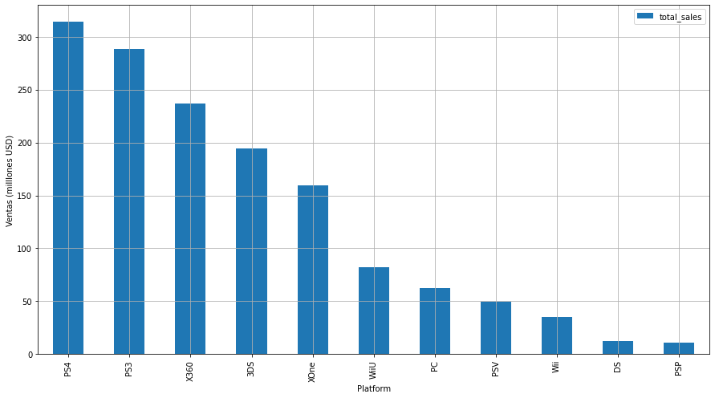

```python
#Calculamos los ingresos medios por consola en los ultimos 5 años
(
    data_actual
    .pivot_table(index='Platform', values='total_sales', aggfunc='sum')
    .sort_values(by='total_sales', ascending=False)
    .plot(kind='bar', ylabel='Ventas (milllones USD)', figsize=(15,8), grid=True)
)
```

En base a lo anterior vemos que para nuestro periodo seleccionado, las plataformas mas relevantes en relación al número de ventas fueron "PS4", "PS3", "X360", "3DS", "XOne" y "WiiU". Poro otro lado, las menos relevantes fueron las plataformas PSP, DS y Wii, las cuales de aquí en adelante no serán consideradas.

```python
plataformas = ["PS4", "PS3", "X360", "3DS", "XOne","WiiU","PC","PSV"]
```

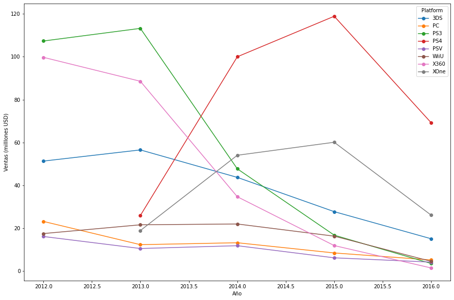

```python
(    data_actual
    .query('Platform==@plataformas')
    .pivot_table(index=('Year_of_Release'),columns='Platform', values='total_sales', aggfunc="sum")
    .plot(kind="line",linestyle='-', marker='o',figsize=(15,10), xlabel='Año', ylabel='Ventas (milllones USD)')
)
```

En la gráfica anterior, vemos que en 2012, las plataformas mas populares eran PS3, X360, seguida de la portatil 3DS. Pero Luego al siguiente año aparecio la siguiente generación de consolas (PS4 y XONE) pasando a ser, con diferencia notable, las mas significativas. Finalmente, en 2016 las plataformas con mayor relevancia, y por consecuencia, mas rentables son **PS4, XOne y 3DS**,a su vez,PS3 y X360 luego del 2014 muestran un continuó descenso de ventas. Respecto a las plataformas PC, WiiU y PSV parecen mostrar un comportamiento relativamente constante en este periodo de tiempo.

### Diagramas de caja, ventas de juegos para principales plataformas

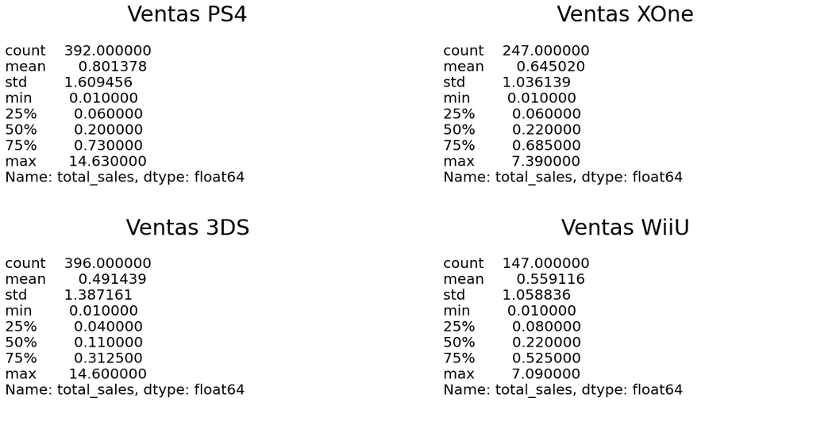

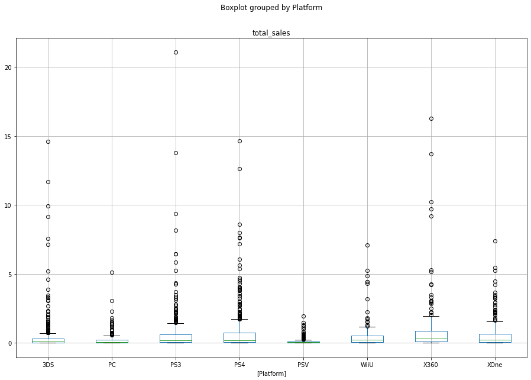

```python
data_actual=data_actual.query('Platform==@plataformas')

fig, axs = plt.subplots(nrows=2, ncols=2, figsize=(20, 10))

aux =data_actual.query('Platform=="PS4"')['total_sales'].describe()
axs[0,0].axis('off')
axs[0,0].set_title("Ventas PS4", fontsize=30)
axs[0,0].text(0, 0.5, str(aux), fontsize=20, va='center')

aux =data_actual.query('Platform=="XOne"')['total_sales'].describe()
axs[0,1].axis('off')
axs[0,1].set_title("Ventas XOne", fontsize=30)
axs[0,1].text(0, 0.5, str(aux), fontsize=20, va='center')

aux =data_actual.query('Platform=="3DS"')['total_sales'].describe()
axs[1,0].axis('off')
axs[1,0].set_title("Ventas 3DS", fontsize=30)
axs[1,0].text(0, 0.5, str(aux), fontsize=20, va='center')


aux =data_actual.query('Platform=="WiiU"')['total_sales'].describe()
axs[1,1].axis('off')
axs[1,1].set_title("Ventas WiiU", fontsize=30)
axs[1,1].text(0, 0.5, str(aux), fontsize=20, va='center')

data_actual.boxplot(column=['total_sales'],by=['Platform'],figsize=(15,10))
plt.xlabel=("Plataformas")
plt.ylabel=("Ventas(millones de dolares)")
```

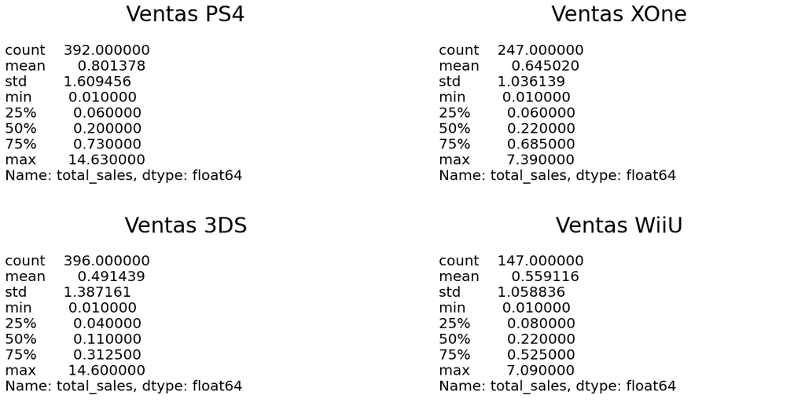

```
(0.0, 2.0)
```

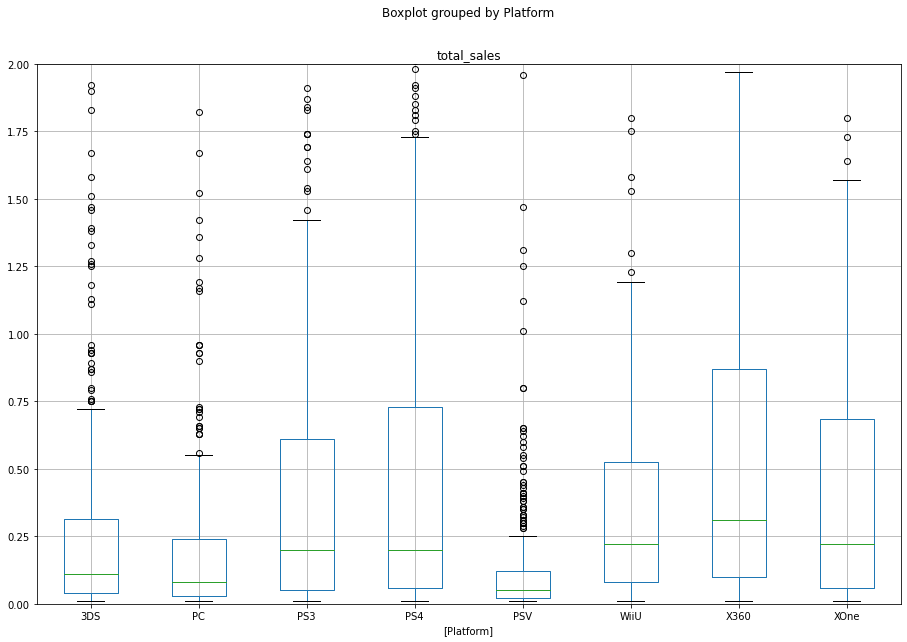

```python
#Miramos un poco mas de cerca
display(fig)
data_actual.boxplot(column=['total_sales'],by=['Platform'],figsize=(15,10))
plt.ylim(0, 2)
```

De las información anterior observamos lo siguiente:

- El ingreso promedio por titulo para la PS4 es de 800.000 dolares.
- El ingreso promedio por titulo para la XOne es de 645.000 dolares.
- El ingreso promedio por titulo para la 3DS es de 490.000 dolares.
- El ingreso promedio por titulo para la WiiU es de 560.000 dolares.
- Los rangos de ingresos tipicos por titulo para la PS4 estan entre 10.000 y 1.750.000 dolares app.
- Los rangos de ingresos tipicos por titulo para la XOne estan entre 10.000 y 1.600.000 dolares app.
- Los rangos de ingresos tipicos por titulo para la 3DS estan entre 10.000 y 750.000 dolares app.
- Los rangos de ingresos tipicos por titulo para la WiiU estan entre 10.000 y 1.200.000 dolares app.
- Para las 4 principales plataformas hay juegos atipicos que generan una cantidad de ingresos mayor a lo normal.

### Ventas vs Reseñas

A continuación buscaré si existe algún tipo de relación entre las reseñas de la crítica y los usuarios, con la venta de los juegos. Dadó que nuestra muestra de calificaciones es limitada. Intentaré buscar la plataforma con mas reseñas registradas para realizar el analisis.

```python
#Contamos el número de calificaciones por usuarios disponibles por consola
#data_actual.query('User_Score>-1').pivot_table(index='Platform',values='User_Score', aggfunc='count')
data_actual.pivot_table(index='Platform',values='User_Score', aggfunc='count')
```

| Platform | User_Score |
| --- | --- |
| 3DS | 114 |
| PC | 206 |
| PS3 | 283 |
| PS4 | 257 |
| PSV | 130 |
| WiiU | 100 |
| X360 | 235 |
| XOne | 182 |

```python
#Contamos el número de calificaciones por la crítica disponibles por consola
#data_actual.query('Critic_Score>-1').pivot_table(index='Platform',values='Critic_Score', aggfunc='count')
data_actual.pivot_table(index='Platform',values='Critic_Score', aggfunc='count')
```

| Platform | Critic_Score |
| --- | --- |
| 3DS | 104 |
| PC | 198 |
| PS3 | 214 |
| PS4 | 252 |
| PSV | 107 |
| WiiU | 90 |
| X360 | 171 |
| XOne | 169 |

```python
aux=257/len(data_actual)
print_mejorado(f"En la consola PS4 hay 257 filas con puntación de los usuarios ({aux:.1%} de los datos) ",20)
aux=252/len(data_actual)
print_mejorado(f"En la consola PS4 hay 252 filas con puntación de la crítica ({aux:.1%} de los datos) ",20)
```

En la consola PS4 hay 257 filas con puntación de los usuarios (9.8% de los datos)

En la consola PS4 hay 252 filas con puntación de la crítica (9.6% de los datos)

#### Reseñas vs ventas (PS4)

Matriz de correlación (Critic_Score/User Score vs Ventas Totales)

|  | Critic_Score | User_Score | total_sales |
| --- | --- | --- | --- |
| Critic_Score | 1.000000 | 0.557654 | 0.406568 |
| User_Score | 0.557654 | 1.000000 | -0.031957 |
| total_sales | 0.406568 | -0.031957 | 1.000000 |

Gráficos de dispersión (Critic_Score/User Score vs Ventas Totales)

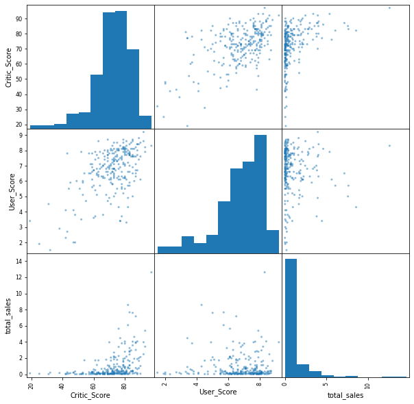

```python
#Creamos una tabla auxiliar que contenga solo los datos que necesitamos
correlacionPS4=data_actual.query('Platform=="PS4"')
#correlacionPS4=correlacionPS4.query('Critic_Score>-1')
#correlacionPS4=correlacionPS4.query('User_Score>-1 ')
correlacionPS4=correlacionPS4[['Name','Critic_Score','User_Score','total_sales']]

#Construimos una matriz de correlación
print_mejorado("Matriz de correlación (Critic_Score/User Score vs Ventas Totales)",20)
display(correlacionPS4.corr())

print("\n")

#Mostramos diagramas de correlación
print_mejorado("Gráficos de dispersión (Critic_Score/User Score vs Ventas Totales)",20)
pd.plotting.scatter_matrix(correlacionPS4, figsize=(10, 10))
plt.show()
```

#### Conclusiones, reseñas vs ventas (PS4)

Del analisis anterior, referente a la plataforma PS4, se concluye lo siguiente:

- Existe una correlación directa (0.4) entre la calificación de la crítica y las ventas totales de cada juego. (A mayor calificación, mas ventas totales)
- No existe una correlación evidente entre la calificación de los usuarios y las ventas totales.

#### Reseñas vs ventas (XOne)

En el punto anterior, investigamos la correlación entré las reseñas y las ventas para la plataforma PS4. A continuación, seleccionaremos los mismos juegos (si es que existen) en una plataforma diferente (XOne) y veremos si las conclusiones anteriores aplican para esta plataforma. Se selecciono XOne debido a la similitud entre ambas plataformas.

De los juegos de PS4 que analizamos, 217 se encuentran en XOne

Matriz de correlación (Critic_Score/User Score vs Ventas Totales)

|  | Critic_Score | User_Score | total_sales |
| --- | --- | --- | --- |
| Critic_Score | 1.000000 | 0.442985 | 0.401749 |
| User_Score | 0.442985 | 1.000000 | -0.110897 |
| total_sales | 0.401749 | -0.110897 | 1.000000 |

Gráficos de dispersión (Critic_Score/User Score vs Ventas Totales)

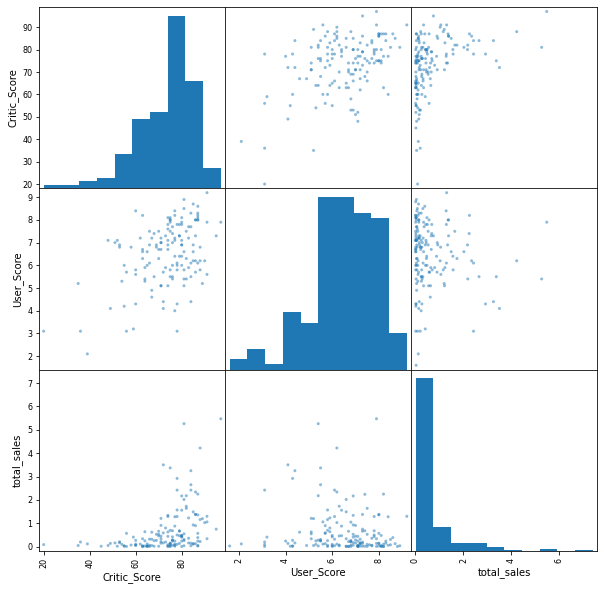

```python
#Hacemos una lista de los juegos analizados anteriormente
juegosPS4=correlacionPS4['Name'].tolist()

#Buscamos estos juegos en la platafomra XOne
correlacion_XONE=data_actual.query('Platform=="XOne"')
correlacion_XONE=correlacion_XONE.query('Name==@juegosPS4')

#Descartamos reseñas nulas
#correlacion_XONE=correlacion_XONE.query('Critic_Score>-1')
#correlacion_XONE=correlacion_XONE.query('User_Score>-1')
correlacion_XONE=correlacion_XONE[['Name','Critic_Score','User_Score','total_sales']]

print_mejorado(f"De los juegos de PS4 que analizamos, {len(correlacion_XONE)} se encuentran en XOne",24)

print("\n")

#Construimos una matriz de correlación
print_mejorado("Matriz de correlación (Critic_Score/User Score vs Ventas Totales)",20)
display(correlacion_XONE.corr())

print("\n")

#Mostramos diagramas de correlación
print_mejorado("Gráficos de dispersión (Critic_Score/User Score vs Ventas Totales)",20)
pd.plotting.scatter_matrix(correlacion_XONE, figsize=(10, 10))
plt.show()
```

#### Conclusiones, reseñas vs ventas (XOne)

Del analisis anterior, referente a la plataforma XOne, se concluye lo siguiente:

Dado que para calcular la correlación en XOne se ocuparon los mismos titulos usados en PS4, se concluye que la influencia de la crítica tiene impactos similares en ambas plataformas.

### Analisis de ganacias por género

A continuación agruparé por tipos de videojuegos (género) y veremos si existen diferencias entre los géneros mas y menos rentables.

```python
def rango_inf (df):
    total_sales=df
    Q1=total_sales.quantile(0.25)
    Q2=total_sales.quantile(0.5)
    Q3=total_sales.quantile(0.75)
    IQR = Q3-Q1
    return (Q2-1.5*IQR)

def rango_sup (df):
    total_sales=df
    Q1=total_sales.quantile(0.25)
    Q2=total_sales.quantile(0.5)
    Q3=total_sales.quantile(0.75)
    IQR = Q3-Q1
    return (Q2+1.5*IQR)

data_genero=(data_actual
    .pivot_table(index='Genre',values='total_sales', aggfunc=('sum','mean','median','max',rango_inf, rango_sup))
    .sort_values(by='sum', ascending=False)
    .rename(columns={'sum': 'ventas', 'mean': 'promedio', 'median': 'mediana'})
    .reindex(columns=['ventas','promedio', 'mediana','rango_inf','rango_sup','max'])
            )
data_genero
```

| Genre | ventas | promedio | mediana | rango_inf | rango_sup | max |
| --- | --- | --- | --- | --- | --- | --- |
| Action | 424.79 | 0.455783 | 0.13 | -0.45500 | 0.71500 | 21.05 |
| Shooter | 304.73 | 1.296723 | 0.44 | -1.57750 | 2.45750 | 14.63 |
| Role-Playing | 179.85 | 0.533680 | 0.16 | -0.42500 | 0.74500 | 14.60 |
| Sports | 177.44 | 0.712610 | 0.26 | -0.79000 | 1.31000 | 8.58 |
| Misc | 66.29 | 0.401758 | 0.13 | -0.36500 | 0.62500 | 9.18 |
| Platform | 58.06 | 0.716790 | 0.21 | -0.66000 | 1.08000 | 9.90 |
| Racing | 53.49 | 0.469211 | 0.15 | -0.41250 | 0.71250 | 7.09 |
| Fighting | 44.13 | 0.420286 | 0.15 | -0.31500 | 0.61500 | 7.55 |
| Simulation | 34.63 | 0.455658 | 0.12 | -0.36375 | 0.60375 | 9.17 |
| Adventure | 27.51 | 0.112286 | 0.04 | -0.06500 | 0.14500 | 1.66 |
| Strategy | 12.37 | 0.187424 | 0.08 | -0.23125 | 0.39125 | 1.67 |
| Puzzle | 4.13 | 0.179565 | 0.05 | -0.07750 | 0.17750 | 1.19 |

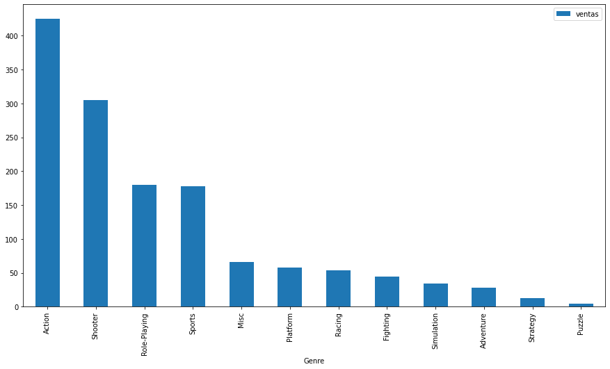

```python
data_genero.plot(kind="bar",y="ventas", figsize=(15,8))
```

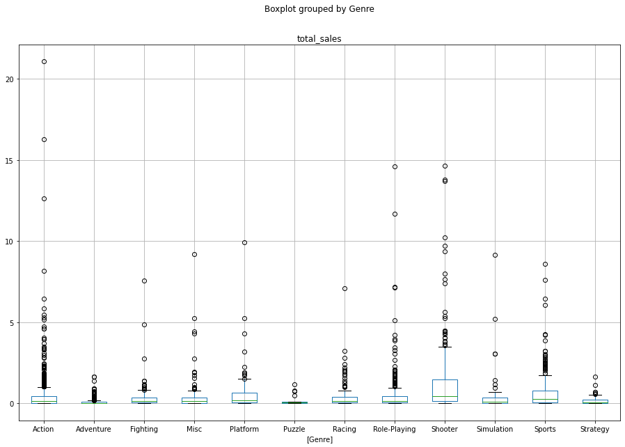

```python
data_actual.boxplot(column=['total_sales'],by=['Genre'],figsize=(15,10))
```

Los géneros mas populares son **Action, Shooting, Role-Playing y Sports**, sin embargo, se deduce que si un juego es de un género en particular no necesariamente implica que un juego individualmente vaya a generar mas o menos ganancias solo por pertener a dicho género, es decir, **no se puede generalizar unicamente considerando el género al que pertenece el juego.**

Esto se aprecia, por ejemplo, observando el género Action, que para el periodo analizado fue el que registró mas ganancias, pero que estas ganancias fue gracias a algunos juegos que sobresalieron de los demás (valores atípicos), cuando la gran mayoria de los juegos de acción registraron ingresos mas bajos.

Otro ejemplo, sería el género Shooter, el cúal, si bien registro ganancias mas bajas que los juegos de Acción, estos juegos tipicamente suelen ser mas rentables.

### Perfil de usuarios por región

#### Plataformas principales por cada región

En este punto veremos las 5 plataformas con mayor numero de ventas en las 3 principales regiones (NA, EU y JP) y veremos si existen diferencia entre cada una de ellas.

```python
#Creamos una función que nos permita rápidamente obtener las ventas totales por plataforma
#asi como las ventas año a año

def plataforma_region(region):
    g1=(data_actual
        .pivot_table(index='Platform', values=(region), aggfunc='sum')
        .sort_values(by=region, ascending=False)
        .head(5)  )

    plat=g1.index.tolist()

    g2= (    data_actual
        .query('Platform==@plat')
        .pivot_table(index=('Year_of_Release'),columns='Platform', values=region, aggfunc="sum")  )

    fig, axs = plt.subplots(nrows=1, ncols=2,figsize=(20,7))
    g1.plot(ax=axs[0],kind='bar', ylabel='Ventas (milllones USD)', grid=True)
    axs[0].set_title(f"Ventas en {region[:2]}", fontsize=30)
    g2.plot(ax=axs[1], kind="line",linestyle='-', marker='o', xlabel='Año', ylabel='Ventas (milllones USD)')
    axs[1].set_title(f"Ventas por año y plataforma en {region[:2]}", fontsize=25)
```

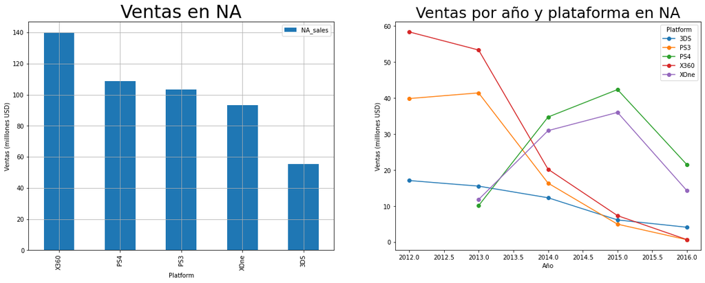

```python
plataforma_region('NA_sales')
```

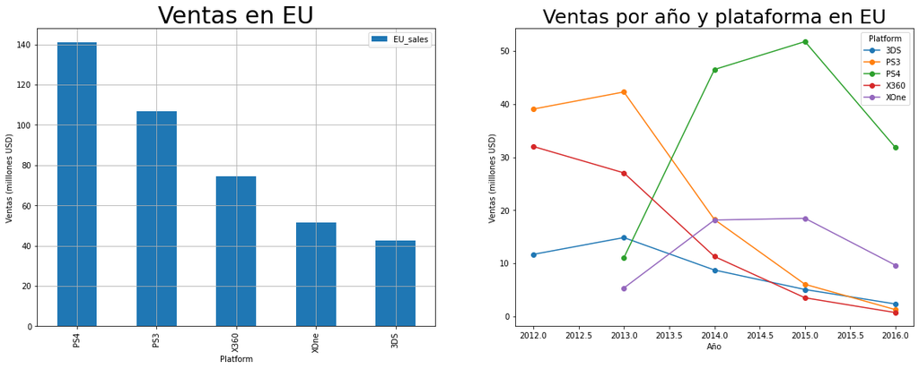

```python
plataforma_region('EU_sales')
```

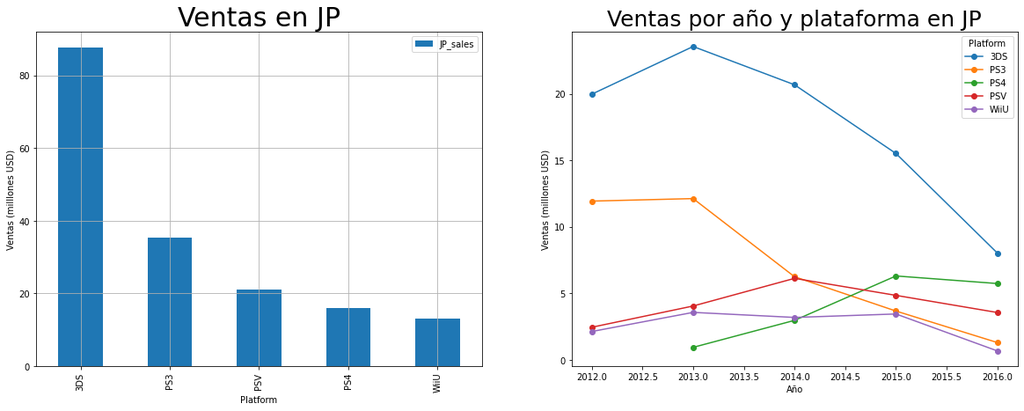

```python
plataforma_region('JP_sales')
```

Los mercados de norteamerica (NA) y Europa (EU) aparentan ser mas o menos similares. En ambos a comienzos del 2012 las plataformas mas populares eran PS3, X360 y 3DS. En 2014 tras la llegada de la nueva generación PS3 y X360 son reemplazadas por PS4 y XOne. Finalmente en el 2016 para estas regiones las plataformas mas populares son PS4 y XOne, mientras que en Europa PS4 parece ser mas popular que XOne.

Con respecto al mercado japones (JP) las cosas parecen un un tanto diferentes. La plataforma mas popular en los 5 años analizados es la portail 3DS. Además las plataformas X360 y XOne son reemplazadas por PSV y WiiU. Finalmente en 2016, las plataformas mas populares son 3DS, PS4 y PSV.